# one-shot-perm-sort

## Pile shuffle/pile sort

Randomizing a deck of cards---aka "shuffling"---is a well-studied problem. However, the majority of the literature focuses on analysis of the common "riffle" shuffle. Because the riffle shuffle is inherently random, a common question is "How many times must the deck be shuffled before it is 'random enough'?"

In contrast, here we study "pile shuffling" (https://kyletreleaven.github.io/pile-shuffle): In pile shuffling the deck is first dealt out, perhaps randomly, into a collection of piles on a table. Then, the piles are reclaimed in some order to reform the deck. The process can be repeated any number of times. Pile shuffling affords us sufficient control over the mechanics of shuffle to ask a different question:

What is the *minimum* number of repetitions we need to shuffle the deck *perfectly*?

### Shuffling vs. sorting

While we introduced the problem as one of randomization, ultimately we are studying *sorting* algorithms. In particular we seek algorithms which are fastest in some sense for sorting *physical* objects with mechanical systems. We will be less concerned, e.g., with optimizing the runtimes of computer algorithms, which generally run on much faster time scales.

Our analysis pertains to shuffling/randomization in two ways:

1. Shuffling is concerned with the manipulation of random permutations (https://en.wikipedia.org/wiki/Permutation), and we will focus exclusively on sorting permutations of a finite ordered set.
2. Any physical sorting algorithm can be used as a physical shuffler with access to a random (virtual) number/permutation generator: First, a random permutation $\sigma$ is generated (this can be done with a https://en.wikipedia.org/wiki/Fisher%E2%80%93Yates_shuffle) and its inverse $\sigma^{-1}$ is computed. If the objects $1..n$ are then physically sorted according to virtual labels $\sigma^{-1}$, then the original labels will appear in the order $\sigma$.

### Sorting Problems

We will consider two physical sorting problems:

**Problem 1** Sort $n$ items in $\theta$ phases with $m$ piles.

With cards as an example, each time the deck is dealt out (each *phase*), at most $m < \infty$ piles may be utilized. We study the problem with piles of either the *queue* type (such as when cards are dealt face up on the top of their piles) or the *stack* type (when they are dealt face down).

**Problem 2** ("One shot" sort) Sort $n$ items in a single (1) phase using any number of piles.

In this (usually impractical) sorting problem, the sort must be completed in a single phase, but without any bound on the number of piles to be used.

Obviously a permutation of size $n < \infty$ can be sorted in a single phase with at most $n$ piles. We are interested in the *minimum* number of piles by which a sort can be achieved in one shot, as a function of the particular permutation.

We study the *surprisingly deep* statistics of the minimum number of piles needed to achieve one-shot sort as a random variable $Y_n$, when the input is a uniformly distributed random permutation of length $n$.

## Optimal Algorithms

### Algorithms for Problem 1 - bounded piles

Elsewhere we have developed optimal algorithms to sort a permutation of size $n$ with constant number $m$ of available piles. In doing so we obtained simple rule(s) depending on the pile type to determine the number of phases required: For now, roughly speaking, a permutation of size $n$ sorts in $\Theta(\log_m Y_n)$ phases with $m$ piles.

This law motivates our interest in the statistics of "one-shot" random permutation sort. We focus the rest of the present analysis on the one-shot sort problem using queues (cards dealt face up), and its statistics.

### Algorithm for Problem 2 - one shot sort

One-shot sort has a straightforward "physical" algorithm that produces the fewest piles:

We iterate the permutation $\sigma = \sigma_1, \sigma_2, \ldots, \sigma_n$. For each element encountered: Place the element $\sigma_i$ on whichever pile has $\sigma_i - 1$ on top. If there's no such pile, place $\sigma_i$ as the start of a new pile.

```python
import bisect

import random
import numpy as np


def create_piles(perm):
    """Simulate the physical process of one-shot pile sort.

    This procedure creates the minimum number of piles needed
    to sort the permutation in one shot.

    """
    piles = []
    for e in perm:
        for pile in piles:  # Not very efficient, oh well.
            if e == pile[-1] + 1:
                pile.append(e)
                break
        else:
            piles.append([e])
    return piles


def sort_piles(piles):
    return sorted(piles, key=lambda pile: pile[0])


def sample_perm(n):
    """Utility method to sample a permutation a size n."""
    perm = np.arange(n)
    random.shuffle(perm)
    return perm


perm = sample_perm(20)
piles = create_piles(perm)
piles_sorted = sort_piles(piles)

perm, piles, piles_sorted, [i for pile in piles_sorted for i in pile]
```

```
(array([ 7, 11,  4,  6, 10, 18, 17,  0,  2, 12,  8, 19, 14,  9,  3, 16,  5,
        15,  1, 13]),
 [[7, 8, 9],
  [11, 12, 13],
  [4, 5],
  [6],
  [10],
  [18, 19],
  [17],
  [0, 1],
  [2, 3],
  [14, 15],
  [16]],
 [[0, 1],
  [2, 3],
  [4, 5],
  [6],
  [7, 8, 9],
  [10],
  [11, 12, 13],
  [14, 15],
  [16],
  [17],
  [18, 19]],
 [0, 1, 2, 3, 4, 5, 6, 7, 8, 9, 10, 11, 12, 13, 14, 15, 16, 17, 18, 19])
```

There's a faster way to "plan" the sort if we have access to a computer. We can determine which elements will start a new pile in $O(n)$ time, by an algorithm similar to Counting sort (https://en.wikipedia.org/wiki/Counting_sort).

```python
def indicate_piles(perm):
    """Determine which elements of a permutation start a new sorting pile.

    A "counting sort" algorithm [1]:
    For each permutation element, determine whether it starts a new pile at the time it is encountered.

    """
    seen = [False] * len(perm)
    new_pile = [True] * len(perm)
    for e in perm:
        seen[e] = True
        if e > 0 and seen[e - 1]:
            new_pile[e] = False
    return new_pile

def num_piles(perm):
    """The number of piles is the sum of the positive events indicated above."""
    return sum(1 for new_pile in indicate_piles(perm) if new_pile)

def create_piles_fast(perm):
    """Create piles quickly using the "counting sort" method (above)."""
    piles = []
    for e, new_pile in enumerate(indicate_piles(perm)):
        if new_pile:
            pile = [e]
            piles.append(pile)
        else:
            pile.append(e)
    return piles

perm = sample_perm(20)
piles = sort_piles(create_piles(perm))
piles_ = create_piles_fast(perm)

perm, piles, piles_
```

```
(array([ 0,  8,  2, 17,  1, 14, 16,  3, 10, 15,  6,  5,  7, 18, 12, 11,  4,
         9, 19, 13]),
 [[0, 1],
  [2, 3, 4],
  [5],
  [6, 7],
  [8, 9],
  [10, 11],
  [12, 13],
  [14, 15],
  [16],
  [17, 18, 19]],
 [[0, 1],
  [2, 3, 4],
  [5],
  [6, 7],
  [8, 9],
  [10, 11],
  [12, 13],
  [14, 15],
  [16],
  [17, 18, 19]])
```

## The minimum number of piles to sort a *random* permutation

The algorithmic part of our study is now finished. In the sequel we focus on the characterization of the number $Y_n$ of piles produced by our algorithm---which is the minimum needed for one-shot sort---when the input is a random permutation of length $n$.

### Main Result

#### Characterization

We will start by stating the fairly remarkable characterization of the distribution of $Y_n$. We will develop this result in the sequel.

First, let $X_n \sim U_{1..n}$ denote a discrete uniformly distributed rv on $1..n$ (https://en.wikipedia.org/wiki/Discrete_uniform_distribution). We have for the discrete uniform distribution :

$${\mathbb E}\left[ X_n \right] = \frac{n + 1}{2}.$$

(Also, ${\rm Var}(X_n) = \frac{n^2 - 1}{12}$.)

Now we introduce a sequence of rvs $(Z_n)_n$:

- Initial condition: Let $Z_1 = 1$; note, $1$ is trivially equal to $X_1$.
- Dilation, $Z_n' = Z_n + \left\lfloor \frac{Z_n - 1}{n} \right\rfloor$.
- Augmentation, $Z_{n+1} = Z_n' + X_{n+1}$.

We will demonstrate that for all $n > 0$, $$Y_n = 1 + \left\lfloor \frac{Z_n - 1}{n} \right\rfloor.$$ (Equality is *in distribution*.)

#### Statistics

We will see that the distributions (PMFs) of $Z_n$ are symmetric and unimodel on support $1..n^2$, and so $${\mathbb E}\left[ Z_n \right] = \frac{n^2 + 1}{2}$$ $${\mathbb E}\left[ Z_n' \right] = {\mathbb E}\left[ Z_{n+1} - X_{n+1} \right] = \frac{n^2 + n}{2}$$ $${\mathbb E}\left[ \left\lfloor \frac{Z_n - 1}{n} \right\rfloor \right] = {\mathbb E}\left[ Z_n' \right] - {\mathbb E}\left[ Z_n \right] = \frac{n - 1}{2}$$

Applying these results we obtain $${\mathbb E} Y_n = \frac{n+1}{2}$$

#### Concentration bounds

Finally, we will argue (conjecture) that $$Z_n \to {\mathcal N}\left( \frac{n^2 + 1}{2}, \frac{n ( n^2 - 1 )}{12} \right),$$

($\mathcal N$ is the Normal distribution) and since we should expect $$\frac{ {\rm Var}(Y_n) }{ {\rm Var}(n^{-1} Z_n) } \to 1$$

then $$Y_n \to {\mathcal N}\left( \frac{n + 1}{2}, \frac{1}{n} \frac{n^2 - 1}{12} \right).$$

We develop these result in the rest of the note.

## Correspondence between permutations and an "insertion process"

We begin by re-conceptualizing a random permutations as the result of a random "insertion process". That is, any permutation can be reconstructed by strategically inserting the ordered elements 1..n into position in a mutable list, as demonstrated below.

```python
import bisect

def get_insertions_for_permutation(perm):
    """

    It is also reasonably straightforward to compute an insertion
    of 1..n that reconstructs a given permutation of length n.
    This correspondence is in fact 1:1. (There are exactly n! insertion profiles of length n.)

    """
    I = np.zeros_like(perm)
    seen = []

    for k, e in enumerate(perm):
        i = bisect.bisect_left(seen, e)
        I[e] = i
        seen.insert(i, e)

    return I

def get_permutation_by_insertions(I):
    """

    Example: [1, 0, 2] results from: inserting 0 into [], then inserting 1 in front of [0], and finally
    inserting 2 at the end of [1, 0].

    Related to:
    * Fisher-Yates shuffle.
        https://en.wikipedia.org/wiki/Fisher%E2%80%93Yates_shuffle#Modern_method
    * Insertion sort
        https://en.wikipedia.org/wiki/Insertion_sort

    """
    result = []
    for e, i in enumerate(I):
        result.insert(i, e)
    return np.array(result, dtype=int)

def sample_insertions(n):
    """

    We don't use it, but:
    It is fairly straightforward to sample uniformly from all insertion profiles.

    Then, given the 1:1 correspondance, we can induce uniform sampling
    from all permutations of the same length
    by transforming the uniform random insertion into a permutation.

    """
    result = np.zeros(n, dtype=int)
    for k in range(n):
        n_ = k + 1
        result[k] = np.random.randint(n_)
    return result


# Demonstrating how an insertion is applied to 1..n.
# Also demonstrating that our perm -> insertion function is inverse function of
# application of the insertion to 1..n.
perm = sample_perm(10)
I = get_insertions_for_permutation(perm)
traj = [get_permutation_by_insertions(I[:n_ + 1]) for n_ in range(len(I))]
perm, I, list(zip(enumerate(I), traj))
```

```
(array([9, 8, 1, 2, 5, 3, 0, 6, 4, 7]),
 array([0, 0, 1, 2, 4, 2, 5, 7, 0, 0]),
 [((0, 0), array([0])),
  ((1, 0), array([1, 0])),
  ((2, 1), array([1, 2, 0])),
  ((3, 2), array([1, 2, 3, 0])),
  ((4, 4), array([1, 2, 3, 0, 4])),
  ((5, 2), array([1, 2, 5, 3, 0, 4])),
  ((6, 5), array([1, 2, 5, 3, 0, 6, 4])),
  ((7, 7), array([1, 2, 5, 3, 0, 6, 4, 7])),
  ((8, 0), array([8, 1, 2, 5, 3, 0, 6, 4, 7])),
  ((9, 0), array([9, 8, 1, 2, 5, 3, 0, 6, 4, 7]))])
```

## Pile creation as a condition on the insertion process

The insertion process is a sequence $( X_i )_{i=1}^n$ of independent random variables with each $X_i$---the next point of insertion---uniformly distributed over $1..i$. (Note, wider by one each iteration.) Each insertion profile of size $n$ corresponds to a permutation of the same length. (Note, there are indeed $n!$ unique insertion profiles. The correspondance is one-to-one.)

(https://www.researchgate.net/publication/220342339_The_Insertion_Encoding_of_Permutations)

The one-shot minimum piles to sort a permutation $Y_n$ can be expressed in terms of a simple condition governing the creation of new piles by the corresponding insertion process:

Specifically, element $i + 1$ starts a new pile upon insertion if and only if element $i$ has not been encountered yet. To say another way, the insertion of element $i + 1$ at location $X_{i+1}$ induces a new pile if and only if it is inserted in front of the previous element $i$ at location $X_i$; i.e., $X_{i+1} \leq X_i$.

Given this condition, the minimum number of piles to sort the associated permutation in one shot is precisely $$Y_n = 1 + \sum_{i=1}^{n-1} \chi_{X_{i+1} \leq X_{i}}$$ where $\chi$ is the indicator function. (You get the first pile for free.)

```python
# Demonstrating the condition for pile count just developed.

def insertion_piles(I):
    """The equation just derived."""
    return 1 + sum(i_ <= i for (i, i_) in zip(I[:-1], I[1:]))

def place_of(i):  # syntax sugar.
    yield i

# Verifying its predictiveness.
[
    (perm, I, num_piles(perm), insertion_piles(I))
    for _ in range(10)
    for perm in place_of(sample_perm(20))
    for I in place_of(get_insertions_for_permutation(perm))
]
```

```
[(array([19,  7,  0,  4,  5,  6, 17,  9, 18,  1,  2, 16, 10,  8, 15, 11, 13,
         12, 14,  3]),
  array([ 0,  1,  2,  3,  1,  2,  3,  0,  7,  5,  8, 10, 11, 11, 13, 10,  8,
          5,  7,  0]),
  9,
  9),
 (array([11, 19,  2,  7, 18,  3, 16, 14, 15,  0,  4, 13,  9,  8, 10,  5,  1,
          6, 17, 12]),
  array([ 0,  1,  0,  1,  3,  4,  6,  1,  5,  5,  7,  0, 12,  6,  4,  5,  4,
         16,  3,  1]),
  10,
  10),
 (array([12, 16, 11,  3, 13, 15, 18, 19,  4, 17,  7,  5,  6, 14,  9,  8,  1,
         10,  2,  0]),
  array([0, 0, 1, 0, 1, 2, 3, 2, 5, 5, 8, 0, 0, 3, 8, 4, 1, 7, 6, 7]),
  10,
  10),
 (array([ 0, 18,  5, 11,  6, 16,  3,  7, 14, 12, 13, 15, 19,  4, 10,  1, 17,
          9,  2,  8]),
  array([ 0,  1,  2,  1,  2,  1,  2,  4,  8,  7,  6,  2,  6,  7,  6,  9,  4,
         14,  1, 12]),
  9,
  9),
 (array([ 0, 18, 16, 12,  5, 13,  7,  4,  8,  2,  1, 11, 15,  3, 17,  9,  6,
         19, 14, 10]),
  array([ 0,  1,  1,  3,  1,  1,  6,  2,  4,  8, 10,  7,  1,  3, 13, 10,  1,
         13,  1, 17]),
  10,
  10),
 (array([ 2, 14, 18, 10,  9,  3,  6,  5,  1, 16, 11,  8, 13,  0,  7, 17, 19,
         15,  4, 12]),
  array([ 0,  0,  0,  1,  4,  2,  2,  6,  5,  1,  1,  7, 12,  9,  1, 13,  8,
         14,  2, 16]),
  12,
  12),
 (array([12,  6, 10,  0, 13, 11, 14,  4,  2,  3, 17,  1,  7, 15, 16, 19,  5,
          8,  9, 18]),
  array([ 0,  1,  1,  2,  1,  5,  0,  6,  8,  9,  1,  3,  0,  4,  6, 12, 13,
         10, 18, 15]),
  8,
  8),
 (array([17, 12, 13,  5, 11,  4, 19,  6,  3, 10, 16,  1,  8, 14,  0, 18,  9,
         15,  2,  7]),
  array([ 0,  0,  2,  0,  0,  0,  2,  7,  5,  7,  4,  1,  0,  1, 10, 13,  8,
          0, 14,  6]),
  12,
  12),
 (array([12,  3,  5,  4,  7, 15, 14,  2,  1, 10, 19,  6, 17, 13,  9,  8, 16,
         11, 18,  0]),
  array([ 0,  0,  0,  0,  1,  1,  5,  3,  7,  7,  6, 10,  0,  9,  5,  5, 14,
         11, 17, 10]),
  13,
  13),
 (array([11,  6,  1, 13, 19, 16,  5,  0, 12,  4, 17, 18, 10, 14,  9,  2, 15,
          7,  8,  3]),
  array([ 0,  0,  2,  3,  2,  1,  0,  6,  7,  5,  5,  0,  5,  3,  9, 12,  4,
          9, 10,  4]),
  11,
  11)]
```

### Relation to $\{0, 1\}$ uniform random walk (aka binomial distribution)

If we consider a random pair of adjacent insertions $X_i, X_{i+1}$ in a pile generating insertion process, then the probability of either ordering of insertion points is as likely as the other:

\begin{align*} {\mathbb P} \left[ X_{i+1} \leq X_i \right] &= \sum_{x=1}^n \frac{1}{n} \sum_{x'=1}^{n+1} \frac{1}{n+1} \chi_{ x' \leq x } \\ &= \frac{1}{n} \frac{1}{n+1} \sum_{x=1}^n x = \frac{1}{2}. \end{align*}

It is tempting then to believe that with every insertion we are as likely to create a new pile as not ($p=0.5$), so that $Y_n$ follows the dynamics of a random walk whose increments are uniformly distributed on $\{0, 1\}$. The position of that random walk at each time $n$ is marginally distributed according to the well known ${\rm Binomial}\left(n, \frac{1}{2}\right)$ distribution.

This intuition is in fact pretty close, but it is unfortunately not quite true, because the number of piles generated until some particular point $n$ actually influences the probability of creating new piles for the continuations of the process. As an extreme example, in case $Y_n = 1$, then we know $\sigma$ is the identity permutation $\sigma^1 = 1..n$, and only the insertion point $n+1$ ($p=\frac{1}{n+1}$) avoids creating another pile to continue the streak. In general, we will see that new piles are more likely in the few-pile regime, whereas conversely, new piles are less likely in the many-pile regime.

In this sense the pile generating insertion process is more "self-regulating" than the random walk (martingale), so we expect a central tendancy *at least* as strong.

On the other hand, we can find strong evidence that the central tendancy is not any stronger *asymptotically*; e.g., it follows the same Power Law:

Consider a derived process $(I_i)_{i=1}^{n}$ \begin{align*} I_i = \begin{cases} 1 & i = 1 \\ \chi_{X_{i} \leq X_{i-1}} & i > 1 \end{cases} \end{align*}

$$Y_n = \sum_{i=1}^n I_i$$

$(I_n)$ is in fact a 1-dependent ("weakly" dependent) random process (https://encyclopediaofmath.org/wiki/M-dependent-process). This is true because $I_{n+2}$ is independent of $I_1, ..., I_n$. ($X_{n+1}$ totally decouples them.)

Although the relevant theorem in Hoeffding is behind a paywall (https://projecteuclid.org/journals/duke-mathematical-journal/volume-15/issue-3/The-central-limit-theorem-for-dependent-random-variables/10.1215/S0012-7094-48-01568-3.short), it sounds like $m$-dependent processes enjoy a Central Limit Theorem similar to the one for independent ($0$-dependent) processes.

In theory then, the two processes are not statistically *so* different. In the sequel we investigate in greater depth.

## In pursuit of a Markov property

Now we begin in earnest in pursuit of the characterization of $Y_n$ given in the prequel.

To that end, we consider a function $N(n, k) = |Y_n = k|$, the number of permutations of length $n$ which produce $k$ piles. However, guided by the equation for $Y_n$ we seek to derive a recurrence equation for a finer tally $N(n, k, i)$; here $n$ and $k$ above are augmented with the insertion point $i$ of the final element. (Indeed the insertion process above enjoys a Markov property on these three statistics.) Then, to obtain the coarser tally we would simply compute $N(n, k) = \sum_{i=1}^n N(n, k, i)$.

Since there is only a single permutation of unit length, we obtain a base case set $N(1, k, i) = 1$ if and only if $k=1$, $i=1$; $0$ otherwise. That is, the final insertion point is (trivially) $1$, and of course it sorts in one shot with a single pile.

For the recurrence, we suppose that the category of a permutation generated so far by an insertion process is $(n, k, i)$. There are always, independently, $n + 1$ possible next insertion points $i'$. According to our pile generation condition, the category of the permutation after the next insertion is $(n + 1, k, i')$ if $i' > i$, or $(n + 1, k+1, i')$ if $i' \leq i$.

```python
import itertools

def tally_permutations_brute_force(N):
    """

    Literally iterate all permutations of length N, and tally by category.
    Runtime N! .

    """
    table = np.zeros((N, N))
    for perm in itertools.permutations(range(N)):
        n_piles = num_piles(perm)
        table[n_piles - 1, np.argmax(perm)] += 1
    return table

def tally_permutations_by_recurrence(N, distr=False):
    """

    Tally by the recurrence logic above. O(N^4) runtime. (But it's way better than n!.)

    """

    table_ = np.zeros((N, N, N))
    # |perm|, |piles|, index of n (largest element)

    # For singleton perm st. |perm| = 1, there's 1 pile, and index is 0
    perm_size, num_piles, index_largest = 1, 1, 0
    table_[perm_size - 1, num_piles - 1, index_largest] = 1

    ns = range(N)  # outer loop
    for i, i_ in zip(ns[:-1], ns[1:]):
        perm_size = i + 1
        perm_size_ = i_ + 1  # Size of next permutation.

        # print(perm_size, perm_size_)

        # inner loops
        for j in range(perm_size):  # always at least one, but can't have more piles than cards :)
            num_piles = j + 1
            for k in range(perm_size):  # index of the largest element currently
                num_perms = table_[i, j, k]

                # Category of prefix specified; now, propagate descendants:

                incr = num_perms  # Recurrence absolute.
                if distr:
                    incr /= perm_size_  # Density recurrence.

                # TODO: This could be vectorized...
                for k_ in range(perm_size_):  # index of the largest element, after insertion
                    # This is the critical insight. Insertion of the next element introduces
                    # a new pile iff it is inserted _before_ the current largest element.
                    num_piles_ = num_piles + 1 if k_ <= k else num_piles
                    i_, j_ = perm_size_ - 1, num_piles_ - 1
                    table_[i_, j_, k_] += incr

    return table_

n = 7
assert n < 8  # Be careful! Runtime, especially of brute force method, gets out of hand quickly.
tally_permutations_brute_force(n), tally_permutations_by_recurrence(n)[-1]
```

```
(array([[  0.,   0.,   0.,   0.,   0.,   0.,   1.],
        [  1.,   2.,   4.,   8.,  16.,  32.,  57.],
        [ 57.,  82., 116., 160., 212., 262., 302.],
        [302., 342., 372., 384., 372., 342., 302.],
        [302., 262., 212., 160., 116.,  82.,  57.],
        [ 57.,  32.,  16.,   8.,   4.,   2.,   1.],
        [  1.,   0.,   0.,   0.,   0.,   0.,   0.]]),
 array([[  0.,   0.,   0.,   0.,   0.,   0.,   1.],
        [  1.,   2.,   4.,   8.,  16.,  32.,  57.],
        [ 57.,  82., 116., 160., 212., 262., 302.],
        [302., 342., 372., 384., 372., 342., 302.],
        [302., 262., 212., 160., 116.,  82.,  57.],
        [ 57.,  32.,  16.,   8.,   4.,   2.,   1.],
        [  1.,   0.,   0.,   0.,   0.,   0.,   0.]]))
```

## Demo: Investigation/Visualization

We can take a moment to examine what we have obtained so far. We can show a "heat map" of the different permutation categories.

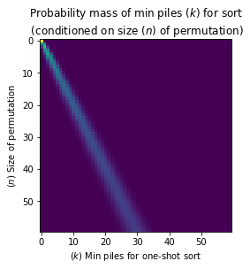

```python
# We can visualize concentration of the min piles for one-shot sort as perm size n increases!
import matplotlib.pyplot as plt

n = 60
assert n < 70  # Beyond there be dragons...
density_evol = tally_permutations_by_recurrence(n, distr=True)  # Compute density rather than count.

pile_size_distr = density_evol.sum(axis=2)  # Marginalize over last insertion point.

plt.imshow(pile_size_distr)
plt.title("Probability mass of min piles ($k$) for sort\n (conditioned on size ($n$) of permutation)")
plt.xlabel("($k$) Min piles for one-shot sort")
plt.ylabel("($n$) Size of permutation")
plt.show()
```

We see that the "beam" concentrates around $k \approx n/2$ as the expected number of piles produced by a permutation of size $n$. We also have fairly strong visual evidence of a Power concentration law.

A quick runtime note:

```python
# This plot would be impossible with the brute force tally!
# Here's how many steps it would take...
import math
math.factorial(n)
```

```
8320987112741390144276341183223364380754172606361245952449277696409600000000000000
```

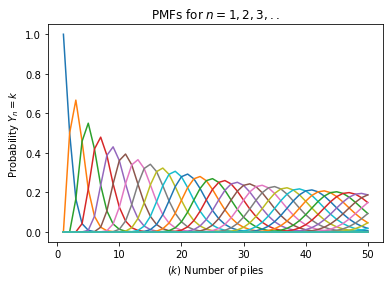

```python
# Would love to be able to characterize/capture the envelope function!
import matplotlib.pyplot as plt

def numbering_of(arr):
    return np.arange(1, len(arr) + 1)

n = 50
density_evol = tally_permutations_by_recurrence(n, distr=True)
pile_size_distr = density_evol.sum(axis=2)

plot_fn = plt.plot

K = pile_size_distr.shape[1]
ks = np.arange(K)
for k in ks:
    ps = pile_size_distr[:, k]
    ns = numbering_of(ps)
    sl = slice(n)
    plot_fn(ns[sl], ps[sl])
    plt.title("PMFs for $n=1, 2, 3, ..$")
    plt.xlabel("($k$) Number of piles")
    plt.ylabel("Probability $Y_n = k$")
```

We reconsider our previous conjecture that $$Y_n \to {\mathcal N}\left( \frac{n + 1}{2}, \frac{1}{n} \frac{n^2 - 1}{12} \right)$$

The mean coincides simply with $\sum_{n'=1}^n {\mathbb E} I_{n'} = 1 + (n-1) \frac{1}{2} = \frac{n+1}{2}$, The variance is derived as $n^{-1}$ times the variance $\frac{n^2 - 1}{12}$ of discrete uniform random variable $X_n$. The latter is developed painstakingly through the sequel.

Let us at least see if our conjecture holds empirically.

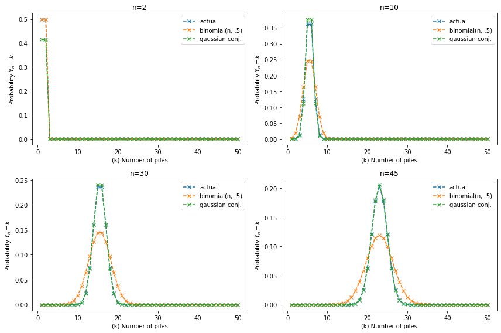

```python
# Compare distributions of $Y_n$, CLT target, and Binomial "bound".
import scipy.stats

ns = [2, 10, 30, 45]  # Sub-sample
n_horizon = n
piles = np.arange(1, n_horizon + 1)


fig = plt.figure(figsize=(12,8))
for k, n_ in enumerate(ns):

    # Actual PMF of piles at n.
    pile_distr = density_evol[n_ - 1].sum(axis=1)[:n_horizon]

    # PMF of p=0.5 binomial rv of same length.
    # Adjustments added for first pile "freebie".
    binom_corr = scipy.stats.binom.pmf(piles - 1, n_ - 1, .5)

    # Conjectured convergence target.
    mu = (n_ + 1) / 2
    var_du = (n_**2 - 1) / 12  # Variance of discrete uniform 1..n
    var = var_du / n_
    gaussian = scipy.stats.norm.pdf(piles, mu, np.sqrt(var))

    def do_labels():
        plt.title(f"n={n_}")
        plt.xlabel("(k) Number of piles")
        plt.ylabel("Probability $Y_n = k$")

    plt.subplot(2, 2, k+1)
    plt.plot(piles, pile_distr, "--", marker="x", label="actual"); do_labels()
    plt.plot(piles, binom_corr, "--", marker="x", label="binomial(n, .5)"); do_labels()
    plt.plot(piles, gaussian, "--", marker="x", label="gaussian conj."); do_labels()
    plt.legend()

fig.tight_layout()
```

Indeed we see that $Y_n$ is noticably tighter than the naive approximation by binomial distribution, but converges quickly to the conjectured normal distribution.

### Insertion point bias

As we suggested earlier, the challenging part of the insertion process $(I_n)$ is that the number of piles influences the distribution of the last insertion point observed by continuations of the process. At this point it is of interest to use the machinery developed so far to glimpse that distribution (conditioned on the number of piles).

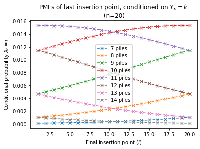

```python
import math

def ints_between(a, b):
    return range(math.ceil(a), math.floor(b) + 1)

n = 20  # For example
density_evol = tally_permutations_by_recurrence(n, distr=True)

n_ = n - 1
t_ = density_evol[n_]
for k in ints_between(n/2 - 3, n/2 + 4):
    k_ = k - 1
    I = t_[k_, :n]
    plt.plot(numbering_of(I), I, label=f"{k} piles", linestyle="--", marker="x")
plt.title(f"PMFs of last insertion point, conditioned on $Y_n = k$ \n (n={n})")
plt.ylabel("Conditional probability $X_n = i$")
plt.xlabel("Final insertion point ($i$)")
plt.legend()
None
```

But there's something going on here. It's like there's a wider function being "wrapped" around a periodic boundary. So let's try to unwrap...?

(Note, this is where the mysterious $Z_n$ starts to come into the picture.)

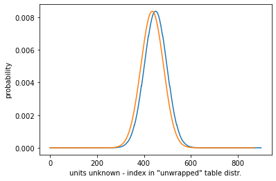

```python
n = 40
density_evol = tally_permutations_by_recurrence(n, distr=True)

n_ = 30
i = n_ - 1

# Unwrap and plot the table distribution.
Z = density_evol[i, :n_, :n_].reshape(-1)  # unwrap
plt.plot(Z)

# (How to characterize this curve?)
# Compare vs. distribution of sum of n iid rv uniform over 1..n
import functools
h_ = functools.reduce(np.convolve, [np.ones(n_) / n_] * n_)
plt.plot(h_)
plt.xlabel('units unknown - index in "unwrapped" table distr.')
plt.ylabel('probability')
None
```

It's... close? We'll have to explore this more a little bit later...

## Symmetry and Expectation(s)

In order to make any more progress, we need to actually derive/prove some statistics about $Y_n$. (And pull in the heavy algebra.)

The recurrence explained above accounts all possible *destinations* of a given permutation category $(n, k, i)$. By considering all possible *sources* instead, we can write the following equivalent forward recurrence equation.

$$N(n+1, k, i) = \sum_{i' < i} N(n, k, i') + \sum_{i' \geq i} N(n, k-1, i')$$

Now we will prove a crucial result that $N(n, \cdot, \cdot)$ survives rotation by $180^\circ$. That is,

$$N(n, n-k+1, n-i+1) = N(n, k, i).$$

The important corollary we are after is the symmetry of $N(n,k)$, i.e., $N(n, n-k+1) = N(n, k)$.

That in turn provides what we need to compute the expected number of piles, since a symmetric distribution---i.e., where $p(\mu + X) = p(\mu - X)$---has ${\mathbb E} X = \mu$.

The corollary provides symmetry of $N$ about

$$\frac{n+1}{2} =: {\mathbb E} Y_n.$$

**Proof**

The proof of rotational symmetry is by induction, with a lot of tedious algebra. Of course, the base case holds trivially with $N(1, k, i) = 1$ iff $k=1$, $i=1$. Next we prove the inductive step.

We apply rotation to the recurrence equation and obtain $$N(n+1, (n+1)-k+1, (n+1)-i+1) = \sum_{i' < (n+1)-i+1} N(n, (n+1)-k+1, i') + \sum_{i' \geq (n+1)-i+1} N(n, [(n+1)-k+1]-1, i')$$

Now we perform a change of variables:

\begin{equation*} \begin{cases} i' = n - j + 1 \\ i' < (n+1)-i + 1 \implies j + 1 > i \implies j \geq i \\ i' \geq (n+1) - i + 1 \implies j < i \\ (n+1) - k + 1 = n - (k-1) + 1 \\ [(n+1)-k+1] - 1 = n-k+1 \end{cases} \end{equation*}

Putting it all together: \begin{align*} N(n+1, (n+1)-k+1, (n+1)-i+1) &= \sum_{j \geq i} N(n, n-(k-1)+1, n-j+1) + \sum_{j<i} N(n, n-k+1, n-j+1) \\ &= \sum_{j<i} N(n, k, j) + \sum_{j \geq i} N(n, k-1, j) \\ &= N(n+1, k, i). \end{align*}

This proves the inductive step.

## "Unraveling" and massaging the recurrence relation

### Probabilistic form

Note, the probabilistic form of the recurrence above is: $$p_{n+1}(k, i) = \frac{1}{n+1} \left[ \sum_{i' < i} p_n(k, i') + \sum_{i' \geq i} p_n(k-1, i') \right].$$

### Unraveling

Motivated by the "wrapping" behavior observed in the insertion point bias above, we apply an "unraveling" trick, with

$$q_n((k-1)n + i) = p_n(k, i).$$

We are at liberty to conjure the new rv $Z_n \sim q_n$ governed by the "unraveled" distribution, which has support on $1..n^2$.

Now "un-raveling" the recurrence, we obtain

\begin{align*} q_{n+1}((k-1)(n+1) + i)) &= \frac{1}{n+1} \left[ \sum_{i'=1}^{i-1} q_n((k-1)n + i') + \sum_{i'=i}^n q_n((k-2)n + i') \right] \\ &= \frac{1}{n+1} \left[ \sum_{j=1}^n q_n((k-1)n + i - j) \right]. \end{align*}

(In the second step we make appropriate variable substitutions for $i'$; $i'=i-j$ and $i' = n + i -j$, respectively.)

This is a powerful result in that it proves $q_n$ is symmetric and unimodal. (Unimodal symmetry is preserved by the action of the "moving average" seen above.)

### Dilation

We still need to do a[nother] little trick now.

Let's introduce $Z_n' \sim q_n'$, with the relation $$q'_n((k-1)(n+1) + i) = q_n((k-1)n +i).$$ (Anywhere else, $q_n'(\cdot) = 0$.)

We do this---"dilate" $q_n$---so that $q_{n+1}$ and $q_n'$ both "ravel with width $n+1$".

This trick relates $Z_n \to Z'_n$ as follows:

$Z_n = (k-1)n + i$ for $i=1..n, k=1..n$, $Z_n=1..n^2$ implies $k-1 = \left\lfloor \frac{Z_n - 1}{n} \right\rfloor$. Then we obtain

\begin{align*} Z_n' &= (k-1)(n+1) + i = Z_n + (k-1) \\ &= Z_n + \left\lfloor \frac{Z_n - 1}{n} \right\rfloor. \end{align*}

(Literally, just injects a zero into the PMF every $n$ spaces. :mindblown:)

### Almost done...

Returning to the main ("unraveled") recurrence, we derive

\begin{align*} q_{n+1}((k-1)(n+1) + i)) &= \frac{1}{n+1} \left[ \sum_{i'=1}^{i-1} q_n((k-1)n + i') + \sum_{i'=i}^n q_n((k-2)n + i') \right] \\ &= \frac{1}{n+1} \left[ \sum_{i'=1}^{i-1} q_n'((k-1)(n+1) + i') + \sum_{i'=i}^n q_n'((k-2)(n+1) + i') \right] \\ &= \frac{1}{n+1} \left[ \sum_{j=1}^{i-1} q_n'((k-1)(n+1) + i - j) + \sum_{j=i+1}^{n+1} q_n'((k-1)(n+1) + i - j) \right] \\ &= \frac{1}{n+1} \left[ \left[ \sum_{j=1}^{n+1} q_n'((k-1)(n+1) + i - j) \right] - q_n'((k-1)(n+1)) \right] \\ &= \frac{1}{n+1} \sum_{j=1}^{n+1} q_n'((k-1)(n+1) + i - j). \end{align*}

In the first line, we rewrote the unraveled recurrence in basic form already seen above. In the second line, we substitute with the "dilated" distribution. In the third line, we perform a change of variables; the two terms undergo *different* changes. In the fourth line, we combine the two summations, while explicitly subtracting the missing case $j = i$. Finally, in the last line, we observe that the missing case is zero by definition of $q_n'$.

Though painstaking, this derivation completes the characterisation of $Z_n$ given as our main result. Note, the final expression denotes convolution with the distribution of discrete uniform rv $X_{n+1}$; such that

$$Z_{n+1} = Z_n' + X_{n+1},$$

where $X_n \sim U_{1..n}$.

## Interpretation: "Wrapping up" an accelerating random walk on a growing 1d lattice

Our developments so far offer another (rather peculiar) re-interpretation of the permutation generating process: Namely, $(Z_n)$ represents an accelerating random walk on a growing $1$-d lattice:

- At step $n$ we advance by $X_n$ (uniformly distributed on $1..n$).
- Then, the environment *grows* (!) by the insertion of a new lattice point every $n$ spaces.
- And we repeat.

Note that at every step, we can "wrap up" $Z_n$, i.e., find the (unique) representation

$$Z_n = (Y_n - 1)n + X'_n$$

such that $Y_n, X'_n > 0$.

By our circuitous construction, $(X'_n)$ is a permutation generating insertion process! Moreover, $(Y_n)$ captures the number of piles generated (so far) at each of its steps.

This is very fascinating and all, but practically speaking, this interpretation allows us to make a remarkable simplification of our recurrence/likelihood equations.

```python
def populate_table_by_dilation(n):
    """

    Re-evaluate the recurrence by dilating of space and velocity, by one (1) each "round".

    """
    table = np.zeros((n, n, n))
    table[0, 0, 0] = 1

    ns = range(1, n + 1)
    for n, n_ in zip(ns[:-1], ns[1:]):
        for pile_index in range(n):
            for insert_index in range(n_):
                w = table[n - 1, pile_index, insert_index]  # / n_

                for k in range(n_):
                    step = k + 1
                    pile_step, insert_index_ = divmod(insert_index + step, n_)
                    pile_index_ = pile_index + pile_step
                    table[n_ - 1, pile_index_, insert_index_] += w

    return table

# Wow, even better!
# Super concise formulation. We don't need any modulus/division logic at all.
# (Well, we make numpy do it...)
PADCONE = ((0,0), (0,1))

def start_table():
    return np.array([[1]])

def increment_table(T, distr=True):
    w, h = T.shape
    assert w == h

    n = w
    n_ = n + 1

    # The pad/dilation is the weird spooky part. It doesn't conform to any
    # operator (e.g., Laplace transforms, etc.) that I really know of.
    # Introduction of a periodic delay?
    x = np.pad(T, PADCONE).reshape(-1)
    h = np.ones(n_ + 1); h[0] = 0
    if distr:
        h /= n_  # for probability.
    return np.convolve(x, h).reshape(n_, n_)

def create_table(n, distr=True):
    table = np.zeros((n, n, n))
    table_ = start_table()
    table[:1, :1, :1] = table_
    for n_ in range(1, n):
        table_ = increment_table(table_, distr)
        table[n_, :n_+1, :n_+1] = table_
    return table
```

```python
# Show that we get the same exact result!
n = 7
tally_permutations_by_recurrence(n)[-1], create_table(n, distr=False)[-1]
```

```
(array([[  0.,   0.,   0.,   0.,   0.,   0.,   1.],
        [  1.,   2.,   4.,   8.,  16.,  32.,  57.],
        [ 57.,  82., 116., 160., 212., 262., 302.],
        [302., 342., 372., 384., 372., 342., 302.],
        [302., 262., 212., 160., 116.,  82.,  57.],
        [ 57.,  32.,  16.,   8.,   4.,   2.,   1.],
        [  1.,   0.,   0.,   0.,   0.,   0.,   0.]]),
 array([[  0.,   0.,   0.,   0.,   0.,   0.,   1.],
        [  1.,   2.,   4.,   8.,  16.,  32.,  57.],
        [ 57.,  82., 116., 160., 212., 262., 302.],
        [302., 342., 372., 384., 372., 342., 302.],
        [302., 262., 212., 160., 116.,  82.,  57.],
        [ 57.,  32.,  16.,   8.,   4.,   2.,   1.],
        [  1.,   0.,   0.,   0.,   0.,   0.,   0.]]))
```

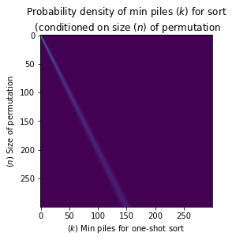

```python
# Still fundamentally O(n^4), but we get a huge speedup from native numpy.
import matplotlib.pyplot as plt

n = 300
density_evol = create_table(n)  # Compute density rather than count.
pile_size_distr = density_evol.sum(axis=2)  # Marginalize over last insertion point; as usual.

idcs, _ = np.indices((n, n))
# boost = np.sqrt(idcs)  # boost intensity for viewing?
boost = 1
beam = pile_size_distr * boost

plt.imshow(beam)
plt.title("Probability density of min piles ($k$) for sort\n (conditioned on size ($n$) of permutation")
plt.xlabel("($k$) Min piles for one-shot sort")
plt.ylabel("($n$) Size of permutation")
plt.show()
```

## Central Tendancy of $Z_n$ (aka halp!)

While I've struggled to prove it, $Z_n$ presents a *very clear* empirical central tendancy, and I'm quite comfortable conjecturing that

$$Z_n \to {\mathcal N}\left( \frac{n^2 + 1}{2}, \frac{n ( n^2 - 1 )}{12} \right).$$

Recall, the mean is actually proved above. For variance our conjecture is that, with rv $S_n$ being a sum of $n$ iid "copies" of (i.e., equal in distribution to) $X_n$, $${\rm Var}( Z_n ) = {\rm Var}\left( S_n \right) = n {\rm Var}(X_n) = \frac{n ( n^2 - 1 )}{12}.$$

We demonstrate below.

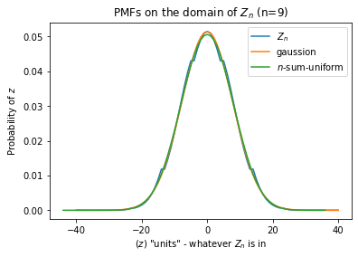

```python
import functools

def get_z_distr(n):
    T = create_table(n)
    qk = T[n-1].reshape(-1)
    return scipy.stats.rv_discrete(values=(numbering_of(qk), qk))

def get_binomial_distr(n, n_of=None):
    n_of = n_of or n
    hs = np.ones(n + 1) / n; hs[0] = 0
    qk = functools.reduce(np.convolve, [hs] * n_of)[1:]
    return scipy.stats.rv_discrete(values=(numbering_of(qk), qk))

n = 9
d1 = get_z_distr(n)
mu1 = (n**2 + 1) / 2

d2 = get_binomial_distr(n)
mu2 = (n**2 + n) / 2

mu_lim = (n**2 + 1) / 2
var_du1 = (n**2 - 1) / 12
var_lim = n * var_du1
q_gaussian = scipy.stats.norm.pdf(d1.xk, mu_lim, np.sqrt(var_lim))

# fig = plt.figure(figsize=(12, 8))
plt.plot(d1.xk - mu1, d1.pk, label="$Z_n$")
plt.plot(d1.xk - mu_lim, q_gaussian, label="gaussion")
plt.plot(d2.xk - mu2, d2.pk, label="$n$-sum-uniform")
plt.title(f"PMFs on the domain of $Z_n$ (n={n})")
plt.legend()
plt.xlabel('($z$) "units" - whatever $Z_n$ is in')
plt.ylabel("Probability of $z$")

if False:
    plt.figure()
    delta = int(mu2 - mu1)
    i = n - 1
    kk = delta
    ys = d2.pk[i + kk:] / d1.pk[i:-kk]

    def reldiff(q, p):
        return (q - p) / p

    rel = reldiff(d2.pk[i + kk:], d1.pk[i:-kk])
    plt.plot(ys)
    # ys_ = np.fft.ifftshift(ys)
    plt.title("")

None
```

I have tried a few attacks, but I think we *might* be able to get what we want by bounding the maximum quantile distance between $Z_n$ and $S_n$. (More accurately, between $\tilde Z_n = Z_n - {\mathbb E} Z_n$ and $\tilde S_n = S_n - {\mathbb E} S_n$, because they actually have different means.)

That is, with the quantile function (inverse cdf) defined as $$F_X^{-1}(q) = \inf \left\{ x : {\mathbb P}(X \leq x) \geq q \right\}$$

we could seek a bound $\Delta_n \in O(1)$ such that $$\sup_q \left| F_{\tilde Z_n}^{-1}(q) - F_{\tilde S_n}^{-1}(q) \right| \leq \Delta_n$$

to obtain a strong bound on the difference of distributions.

Funny enough, the left-hand expression is actually the $p=\infty$ Wasserstein distance $W_{\infty}(\tilde Z_n, \tilde S_n)$, because in one dimension we have (https://en.wikipedia.org/wiki/Wasserstein_metric#One-dimensional_distributions)

$$W_p(X, Y) = \left( \int_0^1 \left| F_X^{-1}(q) - F_Y^{-1}(q) \right|^p {\rm d}q \right)^{1/p}.$$

( Likely, this bound would act as an inductive hypothesis in a proof by induction. At least we have a trivial base given $Z_1 = X_1 = S_1$. )

Empirically it seems to be true (with $\Delta_n = 1$!), except at the very, very ends of the tails.

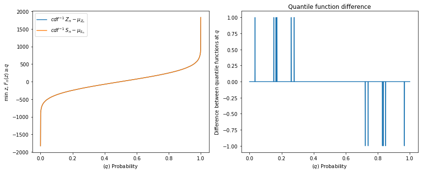

```python
## W_\infty distance; uniformly bounded? can we prove inductively?
n = 101

d1 = get_z_distr(n)
mu1 = (n**2 + 1) / 2

if False:
    # Quick hack. Try dilated n-1 binomial.
    d1 = get_binomial_distr(n-1)
    qk = np.pad(d1.pk.reshape((n-1, n-1)), PADCONE).reshape(-1)
    d1 = scipy.stats.rv_discrete(values=(numbering_of(qk), qk))
    mu1 = d1.mean()

d2 = get_binomial_distr(n)
mu2 = (n**2 + n) / 2

# subtract means
d1 = scipy.stats.rv_discrete(values=(d1.xk - mu1, d1.pk))
d2 = scipy.stats.rv_discrete(values=(d2.xk - mu2, d2.pk))

very_small = 1e-10  # Except _right_ at the ends... set to zero to see them.
# very_small = 0
qs = np.linspace(very_small, 1. - very_small, 1_000)

#Finv1 = d1.xk[np.digitize(qs, d1.pk.cumsum())]
#Finv2 = d2.xk[np.digitize(qs, d2.pk.cumsum())]
Finv1 = d1.ppf(qs)
Finv2 = d2.ppf(qs)

plt.figure(figsize=(12,5))
plt.subplot(121)
plt.plot(qs, Finv1, label="${cdf}^{-1}$ $Z_n - \mu_{Z_n}$")
plt.plot(qs, Finv2, label="${cdf}^{-1}$ $S_n - \mu_{S_n}$")
plt.xlabel("($q$) Probability")
plt.ylabel("min $z$, $F_n(z) \geq q$")
plt.legend()
plt.subplot(122)
n_ = 1
plt.plot(qs, (Finv1 - Finv2) / n_)
plt.title("Quantile function difference")
# plt.plot(qs, (mu1 - mu2) * np.ones_like(qs) / n_, "--", label="$E Z_n - E \sum_n X_n$")
plt.xlabel("($q$) Probability")
plt.ylabel("Difference between quantile functions at $q$")
plt.tight_layout()

# qr = lambda d: (d.cdf(d.xk[0]), d.cdf(d.xk[-1]))
# qr(d1), qr(d2)
```

# STOP HERE (PARTIAL, REDUNDANT, AND/OR INCORRECT RESULTS BELOW THIS POINT)

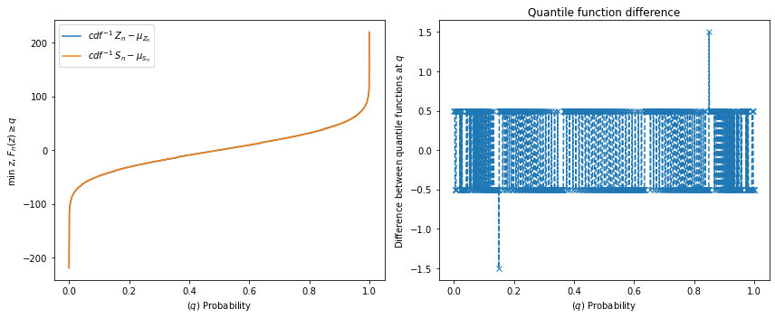

```python
## Compare dilated vs. off-phase binomial
n = 25

# Dilated Z_n, i.e., Z'_n
d1 = get_z_distr(n)
qk = np.pad(d1.pk.reshape((n, n)), PADCONE).reshape(-1)  # dilation
d1 = scipy.stats.rv_discrete(values=(numbering_of(qk), qk))
mu1 = d1.mean()

# n of Bin(n+1, .5)
d2 = get_binomial_distr(n+1, n)  # There's probably a numpy class for this, but...
mu2 = d2.mean()

# subtract means
d1 = scipy.stats.rv_discrete(values=(d1.xk - mu1, d1.pk))
d2 = scipy.stats.rv_discrete(values=(d2.xk - mu2, d2.pk))

very_small = 1e-10  # Except _right_ at the ends... set to zero to see them.
# very_small = 0
qs = np.linspace(very_small, 1. - very_small, 1_000)

Finv1 = d1.ppf(qs)
Finv2 = d2.ppf(qs)

plt.figure(figsize=(12,5))
plt.subplot(121)
plt.plot(qs, Finv1, label="${cdf}^{-1}$ $Z_n - \mu_{Z_n}$")
plt.plot(qs, Finv2, label="${cdf}^{-1}$ $S_n - \mu_{S_n}$")
plt.xlabel("($q$) Probability")
plt.ylabel("min $z$, $F_n(z) \geq q$")
plt.legend()
plt.subplot(122)
n_ = 1
plt.plot(qs, (Finv1 - Finv2) / n_, "--", marker="x")
plt.title("Quantile function difference")
# plt.plot(qs, (mu1 - mu2) * np.ones_like(qs) / n_, "--", label="$E Z_n - E \sum_n X_n$")
plt.xlabel("($q$) Probability")
plt.ylabel("Difference between quantile functions at $q$")
plt.tight_layout()

# qr = lambda d: (d.cdf(d.xk[0]), d.cdf(d.xk[-1]))
# qr(d1), qr(d2)
```

## Concentration Bound

**Upper bound** Because we know that $q_n$ is unimodel and symmetric about its expected value, it is pretty easy to argue that the probability of starting a new pile is $> \frac{1}{2}$ when there is a pile deficiency (vs. expectation) and $< \frac{1}{2}$ when there is a surplus. In other words, the process is somewhat self-regulating, and so it must concentrate *at least* as much as the uniform $\{0, 1\}$-random walk, whose distribution at any $n$ is simply the $p=\frac{1}{2}$ binomial distribution, with variance $\frac{1}{4}n$.

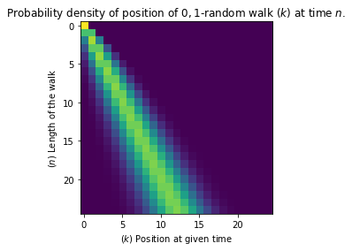

```python
binom = np.zeros((n, n))
r = np.array([1])
k = np.array([.5, .5])
for i in range(n):
    n_ = i + 1
    binom[i, :n_] = np.sqrt(n_) * r
    r = np.convolve(r, k)

plt.imshow(binom)
plt.title("Probability density of position of ${0, 1}$-random walk ($k$) at time $n$.")
plt.xlabel("($k$) Position at given time")
plt.ylabel("($n$) Length of the walk")
plt.show()
```

**Lower bound**

So we can show (below) $$\frac{n+1}{n} Z_n - 1 \leq Z_n' = Z_n + \left\lfloor \frac{Z_n -1}{n} \right\rfloor \leq \frac{n+1}{n} Z_n - \frac{1}{n}$$

**(TODO: Below is wrong :( --- but try on the other side where quantities are positive!)**

[output not shown]

This gives us a recurrence $${\rm Var}\left( Z_{n+1} \right) \geq \left( \frac{n+1}{n} \right)^2 {\rm Var}\left( Z_n \right) + {\rm Var}\left( X_{n+1} \right).$$

which lets us obtain $${\rm Var}\left( Z_n \right) \geq \sum_{n'=1}^n \left(\frac{n}{n'}\right)^2 {\rm Var}\left( X_{n'} \right) \in \sum_{n'=1}^n \left(\frac{n}{n'}\right)^2 \Omega(n'^2) = \sum_{n'=1}^n \Omega(n^2) = \Omega(n^3).$$

This power law is asymptotically tight since we matched it from above with that of the random walk, i.e., binomial random variable.

```python
# Constructing pmfs for discrete rvs Z_n
import scipy.stats

def numbering_of(arr):
    return np.arange(1, len(arr) + 1)

ps = []
qs = []
for k, t_ in enumerate(density_evol):
    n_ = k + 1
    zk = t_[:n_, :n_]
    pk = zk.sum(axis=1)
    p = scipy.stats.rv_discrete(values=(numbering_of(pk), pk))
    ps.append(p)

    qk = zk.reshape(-1)
    q = scipy.stats.rv_discrete(values=(numbering_of(qk), qk))
    qs.append(q)


def fit_line(p1, p2):
    """to two points. easy.

    y1 = m x1 + b
    y2 = m x2 + b

    m = (y2 - y1) / (x2 - x1)
    b = y1 - m * x1

    """
    x1, y1 = p1
    x2, y2 = p2
    m = (y2 - y1) / (x2 - x1)
    b = y1 - m * x1
    return m, b

def eval(k):
    return (
        np.log(k+1),         # log n
        np.log(qs[k].var())  # log var Zn
    )

k1, k2 = [15, 150]
m, b = fit_line(eval(k1), eval(k2))
# V = exp(b) * n^m
k1, k2, np.exp(b), m
```

```
(15, 150, 0.08184902506380207, 3.0035645264989164)
```

[output not shown]

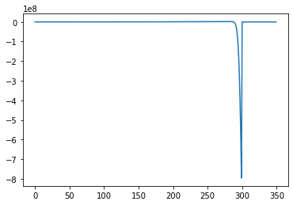

```python
n = 50
binom_evol = np.zeros((n, n**2))

import functools
for i in range(n):
    n_ = i + 1
    hs = np.ones(n_) / n_
    xs = functools.reduce(np.convolve, [hs] * n_)
    binom_evol[i, :len(xs)] = xs

ps = []
qs_density = []
qs_binom = []
for k, t_ in enumerate(binom_evol):
    n_ = k + 1
    qk = t_
    q = scipy.stats.rv_discrete(values=(numbering_of(qk), qk))
    qs.append(q)

plt.plot([q.var() for q in qs])

def eval(k):
    return (
        np.log(k+1),         # log n
        np.log(qs[k].var())  # log var Zn
    )

k1, k2 = [15, 49]
m, b = fit_line(eval(k1), eval(k2))
# V = exp(b) * n^m
k1, k2, np.exp(b), m
```

```python
scipy.stats.norm.pdf(0, 0, 1)
```

```
0.3989422804014327
```

```python
hs = np.ones(4 + 1); hs[0] = 0
n = 7
pk = functools.reduce(np.convolve, [hs] * n)[1:]
# np.convolve(hs, hs)[:]
pk.shape, 4 * n, pk
ys_[:10]

np.fft.fftfreq?
```

[output not shown]

```python
for k in range(10, 200, 20):
    plt.plot(binom_evol[k])
```

```python
n = 2
zs = np.arange(n**2) + 1
mu = (n**2 + 1) / 2
res = np.floor((zs - 1)/n)
mu_ = (n-1)/2

zs_ = zs + res

plt.subplot(211)
plt.plot(zs, zs, zs, res, zs, zs_, linestyle="--", marker="x")
plt.subplot(212)
plt.plot(zs, zs - mu, zs, res - mu_, zs, zs + res - mu - mu_, linestyle="--", marker="x")
```

```python
f = lambda n: math.ceil((n**2 + 1) / 2) - 1
[f(n) for n in range(1, 10+1)]
```

```python
def fit_line(p1, p2):
    """to two points. easy.

    y1 = m x1 + b
    y2 = m x2 + b

    m = (y2 - y1) / (x2 - x1)
    b = y1 - m * x1

    """
    x1, y1 = p1
    x2, y2 = p2
    m = (y2 - y1) / (x2 - x1)
    b = y1 - m * x1
    return m, b

n = 4
zs = np.arange(n**2) + 1
mu = (n**2 + 1) / 2
res = np.floor((zs - 1)/n)
mu_ = (n-1)/2

zs_ = zs + res
m_upper, b_upper = fit_line((zs[0], zs_[0]), (zs[n], zs_[n]))
m_lower, b_lower = fit_line((zs[n-1], zs_[n-1]), (zs[2*n-1], zs_[2*n-1]))

k = 1000
zs_upper = m_upper * zs + b_upper
plt.plot(zs[:k], (zs + res)[:k], linestyle="--", marker="x")
zs_lower = m_lower * zs + b_lower
plt.plot(zs[:k], zs_upper[:k], zs[:k], zs_lower[:k])

m_upper, b_upper, m_lower, b_lower
```

```python
# Is variance really _more_ than expected?
# Verify empirically...

import scipy.stats

n = 15
density_evol = create_table(n)  # Compute density rather than count.

def check(n_):
    i = n_ - 1
    m = density_evol[i][:n_, :n_]
    z = m.reshape(-1)
    z_ = np.pad(m, ((0, 0), (0, 1))).reshape(-1)

    q = scipy.stats.rv_discrete(values=(numbering_of(z), z))
    q_ = scipy.stats.rv_discrete(values=(numbering_of(z_), z_))
    v = q.var()
    v_ = q_.var()
    c = ((n_ + 1) / n_)**2

    # variance discrete uniform X_{n+1} (added)
    v2 = ((n_ + 1)**2 - 1) / 12

    return v, c * v, v_, v2, v_ + v2

[
    check(n_)
    for n_ in range(1, 10 + 1)
]  # Wow. Works absolutely perfectly...
```

```python
import functools

def get_row_binom(n, distr=True):
    hs = np.ones(n + 1); hs[0] = 0
    if distr:
        hs /= n
    return functools.reduce(np.convolve, [hs] * n)[1:]

def create_table_binom(n, distr=True):
    t = np.zeros((n, n, n))
    for i in range(n):
        n_ = i + 1
        t[i, :n_, :n_] = get_row_binom(n_, distr).reshape((n_, n_))
    return t

create_table(10, distr=True)[-1] - create_table_binom(10, True)[-1]
```